# jekyll-jupyter-notebook20250824-3755-ctei4y

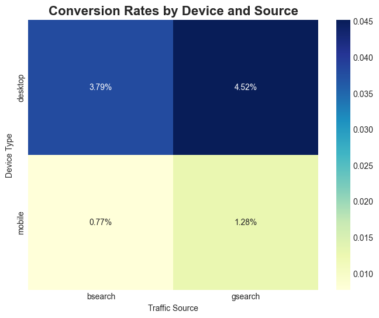

```python
# --- Execute Query for Conversion Rates ---
df_conversion_rates = pd.read_sql(sql_queries[2], engine)

# --- Visualization ---
plt.figure(figsize=(8, 6))
conversion_pivot = df_conversion_rates.pivot_table(index='device_type', columns='utm_source', values='conv_rate')
sns.heatmap(conversion_pivot, annot=True, fmt=".2%", cmap="YlGnBu")
plt.title('Conversion Rates by Device and Source', fontsize=16, fontweight='bold')
plt.xlabel('Traffic Source')
plt.ylabel('Device Type')
plt.show()
```

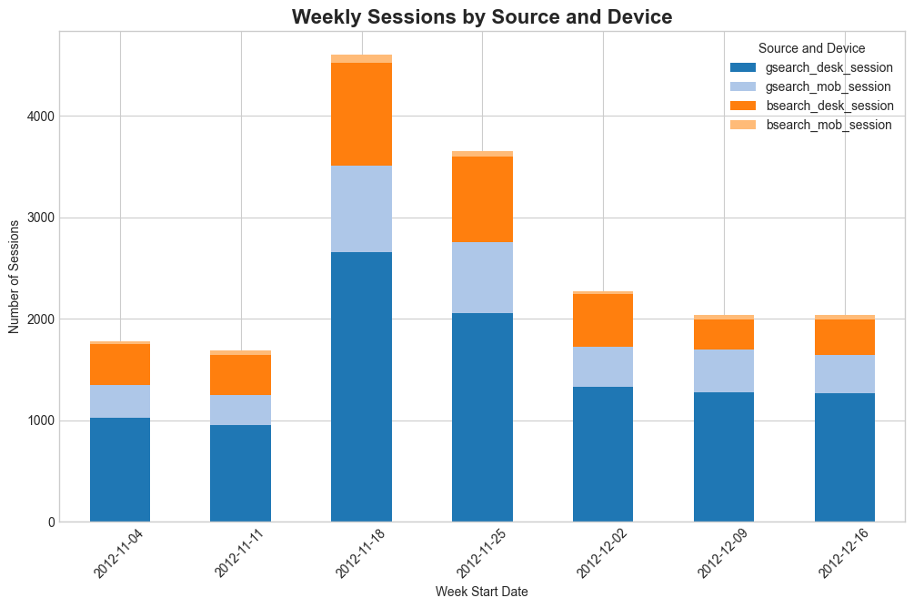

```python
# --- Execute Query for Weekly Detailed Breakdown ---
df_weekly_detailed = pd.read_sql(sql_queries[3], engine)

# --- Visualization ---
df_weekly_detailed.plot(
    x='wk',
    y=['gsearch_desk_session', 'gsearch_mob_session', 'bsearch_desk_session', 'bsearch_mob_session'],
    kind='bar',
    stacked=True,
    figsize=(12, 7),
    color=['#1f77b4', '#aec7e8', '#ff7f0e', '#ffbb78']
)
plt.title('Weekly Sessions by Source and Device', fontsize=16, fontweight='bold')
plt.xlabel('Week Start Date')
plt.ylabel('Number of Sessions')
plt.xticks(rotation=45)
plt.legend(title='Source and Device')
plt.show()
```

```python
# --- Read Queries for A/B Test Analysis ---
# Query to get weekly bounce rates and traffic distribution for the A/B test
with open('02_user_behavior_and_funnels/landing-page-trend-analysis-012.sql', 'r') as file:
    query = """
    select
        min(date(session_created_at)) as week_start_date,
        (count(distinct case when pv_count = 1 then website_session_id else null end) / count(distinct website_session_id)) * 100 as bounce_rate,
        count(distinct case when landing_page = '/home' then website_session_id else null end) as home_sessions,
        count(distinct case when landing_page = '/lander-1' then website_session_id else null end) as lander_1_sessions
    from (
        select
            s_with_first_pv_and_pv_count.website_session_id,
            s_with_first_pv_and_pv_count.first_pv,
            s_with_first_pv_and_pv_count.pv_count,
            website_pageviews.pageview_url as landing_page,
            website_pageviews.created_at as session_created_at
        from (
            select
                website_sessions.website_session_id,
                min(website_pageviews.website_pageview_id) as first_pv,
                count(website_pageviews.website_pageview_id) as pv_count
            From website_sessions
                left join website_pageviews
                    on website_sessions.website_session_id = website_pageviews.website_session_id
            where website_sessions.created_at > '2012-06-01'
                and website_sessions.created_at < '2012-08-31'
                and website_sessions.utm_source = 'gsearch'
                and website_sessions.utm_campaign = 'nonbrand'
            group by 1
        ) as s_with_first_pv_and_pv_count
        left join website_pageviews
            on website_pageviews.website_pageview_id = s_with_first_pv_and_pv_count.first_pv
    ) as s_with_pv_count_landing_page_created_at
    group by yearweek(session_created_at)
    """
df_ab_test_trends = pd.read_sql(query, engine)


# 3. Product Pathing Analysis
with open('02_user_behavior_and_funnels/product-pathing-analysis.sql', 'r') as file:
    sql_queries = file.read().split(';')
sql_queries = [q.strip() for q in sql_queries if q.strip()]
# We need to construct the final query from the file
final_pathing_query = """
select
	time_period,
    count(distinct website_session_id) as sessions,
    count(distinct case when next_pv_url = '/the-original-mr-fuzzy' then website_session_id else null end) as to_mr_fuzzy,
    count(distinct case when next_pv_url = '/the-forever-love-bear' then website_session_id else null end) as to_love_bear
from (
    select
        sessions_with_next_pv.website_session_id,
        sessions_with_next_pv.time_period,
        website_pageviews.pageview_url as next_pv_url
    from (
        select
            products_pageviews.website_session_id,
            products_pageviews.time_period,
            min(website_pageviews.website_pageview_id) as min_next_pv
        from (
            select
                website_sessions.website_session_id,
                website_pageviews.website_pageview_id,
                website_pageviews.pageview_url,
                website_sessions.created_at,
                case when website_sessions.created_at < '2013-01-06' then 'A. Pre_Product_2'
                     when website_sessions.created_at > '2013-01-06' then 'B. Post_Product_2'
                     else 'check logic'
                     end time_period
            from website_sessions
                left join website_pageviews
                    on website_pageviews.website_session_id = website_sessions.website_session_id
            where website_sessions.created_at > '2012-10-06'
                and website_sessions.created_at < '2013-04-01'
                and website_pageviews.pageview_url = '/products'
        ) as products_pageviews
        left join website_pageviews
            on website_pageviews.website_session_id = products_pageviews.website_session_id
            and website_pageviews.website_pageview_id > products_pageviews.website_pageview_id
        group by 1,2
    ) as sessions_with_next_pv
    left join website_pageviews
        on website_pageviews.website_pageview_id = sessions_with_next_pv.min_next_pv
) as sessions_with_next_pv_url
group by 1;
"""
df_pathing = pd.read_sql(final_pathing_query, engine)

# 4. Sales and Product Launches
with open('04_sales_and_product_analytics/anylising-products-sales-and-products-launches.sql', 'r') as file:
    sql_queries = file.read().split(';')
sql_queries = [q.strip() for q in sql_queries if q.strip()]

df_sales = pd.read_sql(sql_queries[0], engine)
```

## Explanation:

The Technical Reason: Temporary Tables Here’s a quick breakdown of the issue:

How Temporary Tables Work: When you run a query like CREATE TEMPORARY TABLE ..., that table only exists for your current, active connection to the database. As soon as you disconnect, it vanishes.

How pandas.read_sql() Works: Each time you call pd.read_sql(), it typically opens a new, fresh connection to the database, runs the query, gets the results, and then closes that connection.

The Conflict: If I were to run your scripts as-is, the first call would create the temporary table and then immediately disconnect, causing the table to be destroyed. The very next line of code to SELECT from that table would fail because the table no longer exists.

To solve this, I rewrite the logic from your multi-step scripts (which use temporary tables) into a single, self-contained query using subqueries. This ensures that all the logic is executed on the database in one go, on a single connection, so pandas can receive the final result.

So, while it looks like I'm rewriting them, I'm actually just refactoring them to be compatible with the Python environment while preserving the original analytical logic.

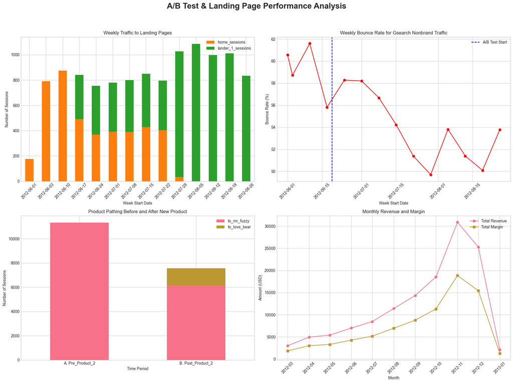

```python
# --- Visualization ---
fig, axes = plt.subplots(2, 2, figsize=(18, 14))
fig.suptitle('A/B Test & Landing Page Performance Analysis', fontsize=20, fontweight='bold')

# 1. Traffic Distribution During A/B Test
df_ab_test_trends.plot(
    x='week_start_date', y=['home_sessions', 'lander_1_sessions'], kind='bar', stacked=True,
    ax=axes[0, 0], color=['#ff7f0e', '#2ca02c']
)
axes[0, 0].set_title('Weekly Traffic to Landing Pages')
axes[0, 0].set_xlabel('Week Start Date')
axes[0, 0].set_ylabel('Number of Sessions')
axes[0, 0].tick_params(axis='x', rotation=45)


# 2. Bounce Rate Trends During A/B Test
axes[0, 1].plot(df_ab_test_trends['week_start_date'], df_ab_test_trends['bounce_rate'], marker='o', color='r')
axes[0, 1].set_title('Weekly Bounce Rate for Gsearch Nonbrand Traffic')
axes[0, 1].set_xlabel('Week Start Date')
axes[0, 1].set_ylabel('Bounce Rate (%)')
axes[0, 1].tick_params(axis='x', rotation=45)
# Add a line to show when the test started
axes[0, 1].axvline(pd.to_datetime('2012-06-19'), color='blue', linestyle='--', label='A/B Test Start')
axes[0, 1].legend()

df_pathing.set_index('time_period')[['to_mr_fuzzy', 'to_love_bear']].plot(kind='bar', stacked=True, ax=axes[1, 0])
axes[1, 0].set_title('Product Pathing Before and After New Product')
axes[1, 0].set_xlabel('Time Period')
axes[1, 0].set_ylabel('Number of Sessions')
axes[1, 0].tick_params(axis='x', rotation=0)

df_sales['date'] = pd.to_datetime(df_sales['yr'].astype(str) + '-' + df_sales['mo'].astype(str))
axes[1, 1].plot(df_sales['date'], df_sales['total_revenue'], label='Total Revenue', marker='o')
axes[1, 1].plot(df_sales['date'], df_sales['total_margin'], label='Total Margin', marker='s')
axes[1, 1].set_title('Monthly Revenue and Margin')
axes[1, 1].set_xlabel('Month')
axes[1, 1].set_ylabel('Amount (USD)')
axes[1, 1].legend()
axes[1, 1].tick_params(axis='x', rotation=45)


plt.tight_layout(rect=[0, 0.03, 1, 0.95])
plt.show()
```

```python
# --- Read Queries for the Final Recap ---
# We will execute each query from the recap file individually to build the dashboard

# Query 1: Traffic Source Breakdown
q1 = "SELECT utm_source, utm_campaign, http_referer, COUNT(website_session_id) AS sessions FROM website_sessions WHERE created_at < '2012-04-12' GROUP BY utm_source, utm_campaign, http_referer ORDER BY sessions DESC;"
df_traffic_sources = pd.read_sql(q1, engine)

# Query 2: Gsearch Nonbrand Conversion Rate
q2 = "SELECT COUNT(DISTINCT ws.website_session_id) AS sessions, COUNT(DISTINCT o.order_id) AS orders FROM website_sessions ws LEFT JOIN orders o ON o.website_session_id = ws.website_session_id WHERE ws.created_at <= '2012-04-14' AND utm_source = 'gsearch' AND utm_campaign = 'nonbrand';"
df_gsearch_cvr = pd.read_sql(q2, engine)
gsearch_conversion_rate = (df_gsearch_cvr['orders'][0] / df_gsearch_cvr['sessions'][0]) * 100

# Query 3: Gsearch Nonbrand Weekly Volume Trends
q3 = "SELECT MIN(DATE(created_at)) AS week_start_date, COUNT(DISTINCT website_session_id) AS sessions FROM website_sessions WHERE created_at < '2012-05-10' AND utm_source = 'gsearch' AND utm_campaign = 'nonbrand' GROUP BY YEARWEEK(created_at) ORDER BY week_start_date;"
df_weekly_volume = pd.read_sql(q3, engine)

# Query 4: Device-Level Conversion Rates
q4 = "SELECT ws.device_type, COUNT(DISTINCT ws.website_session_id) AS sessions, COUNT(DISTINCT o.order_id) AS orders FROM website_sessions ws LEFT JOIN orders o ON o.website_session_id = ws.website_session_id WHERE ws.created_at < '2012-05-11' AND utm_source = 'gsearch' AND utm_campaign = 'nonbrand' GROUP BY ws.device_type;"
df_device_performance = pd.read_sql(q4, engine)
df_device_performance['conversion_rate'] = (df_device_performance['orders'] / df_device_performance['sessions']) * 100

# Query 5: Top Website Pages
q5 = "SELECT pageview_url, COUNT(DISTINCT website_session_id) AS sessions FROM website_pageviews WHERE created_at < '2012-06-09' GROUP BY pageview_url ORDER BY sessions DESC;"
df_top_pages = pd.read_sql(q5, engine).head(7) # Top 7 pages for the funnel

# Query 6: Monthly Business Performance
q6 = "SELECT YEAR(ws.created_at) as yr, MONTH(ws.created_at) as mo, COUNT(DISTINCT ws.website_session_id) as total_sessions, COUNT(DISTINCT o.order_id) as total_orders FROM website_sessions ws LEFT JOIN orders o ON ws.website_session_id = o.website_session_id WHERE ws.created_at >= '2012-03-01' AND ws.created_at < '2012-07-01' GROUP BY 1, 2 ORDER BY 1, 2;"
df_monthly_performance = pd.read_sql(q6, engine)
df_monthly_performance['conversion_rate'] = (df_monthly_performance['total_orders'] / df_monthly_performance['total_sessions']) * 100
```

[output not shown]

[figure not shown]

```python
# --- Comprehensive Visualization ---
fig, axes = plt.subplots(2, 3, figsize=(22, 14))
fig.suptitle('Maven Fuzzy Factory - Comprehensive Business Recap (2012)', fontsize=24, fontweight='bold')

# 1. Traffic Source Breakdown
gsearch_sessions = df_traffic_sources[df_traffic_sources['utm_source'] == 'gsearch']['sessions'].sum()
bsearch_sessions = df_traffic_sources[df_traffic_sources['utm_source'] == 'bsearch']['sessions'].sum()
direct_sessions = df_traffic_sources[df_traffic_sources['utm_source'].isnull()]['sessions'].sum()
traffic_data = pd.DataFrame({'source': ['gsearch', 'direct', 'bsearch'], 'sessions': [gsearch_sessions, direct_sessions, bsearch_sessions]})
axes[0, 0].pie(traffic_data['sessions'], labels=traffic_data['source'], autopct='%1.1f%%', startangle=90, colors=['#1f77b4', '#2ca02c', '#ff7f0e'])
axes[0, 0].set_title('Traffic Source Distribution (Pre-April 12)', fontweight='bold')

# 2. Gsearch Nonbrand Weekly Volume
axes[0, 1].plot(df_weekly_volume['week_start_date'], df_weekly_volume['sessions'], marker='o', color='b')
axes[0, 1].set_title('Gsearch Nonbrand Weekly Sessions (Pre-May 10)', fontweight='bold')
axes[0, 1].set_xlabel('Week')
axes[0, 1].set_ylabel('Sessions')
axes[0, 1].tick_params(axis='x', rotation=45)

# 3. Device Performance
sns.barplot(x='device_type', y='conversion_rate', data=df_device_performance, ax=axes[0, 2])
axes[0, 2].set_title('Gsearch Nonbrand CVR by Device (Pre-May 11)', fontweight='bold')
axes[0, 2].set_xlabel('Device Type')
axes[0, 2].set_ylabel('Conversion Rate (%)')
axes[0, 2].yaxis.set_major_formatter(plt.FuncFormatter(lambda y, _: f'{y:.2f}%'))

# 4. Website Conversion Funnel
sns.barplot(x='sessions', y='pageview_url', data=df_top_pages, ax=axes[1, 0], palette='viridis')
axes[1, 0].set_title('Top Website Pages Funnel (Pre-June 9)', fontweight='bold')
axes[1, 0].set_xlabel('Number of Sessions')
axes[1, 0].set_ylabel('Page')

# 5. Monthly Performance - Sessions & Orders
axes[1, 1].plot(df_monthly_performance.index, df_monthly_performance['total_sessions'], label='Total Sessions', marker='o')
axes[1, 1].plot(df_monthly_performance.index, df_monthly_performance['total_orders'], label='Total Orders', marker='s')
axes[1, 1].set_title('Monthly Sessions & Orders (Mar-Jun)', fontweight='bold')
axes[1, 1].set_xticks(df_monthly_performance.index)
axes[1, 1].set_xticklabels([f"{row['yr']}-{row['mo']:02d}" for idx, row in df_monthly_performance.iterrows()])
axes[1, 1].legend()

# 6. Monthly Performance - Conversion Rate
axes[1, 2].plot(df_monthly_performance.index, df_monthly_performance['conversion_rate'], label='Conversion Rate', color='g', marker='^')
axes[1, 2].set_title('Monthly Conversion Rate (Mar-Jun)', fontweight='bold')
axes[1, 2].set_xticks(df_monthly_performance.index)
axes[1, 2].set_xticklabels([f"{row['yr']}-{row['mo']:02d}" for idx, row in df_monthly_performance.iterrows()])
axes[1, 2].set_ylabel('Conversion Rate (%)')
axes[1, 2].yaxis.set_major_formatter(plt.FuncFormatter(lambda y, _: f'{y:.2f}%'))
axes[1, 2].legend()


plt.tight_layout(rect=[0, 0.03, 1, 0.95])
plt.show()
```

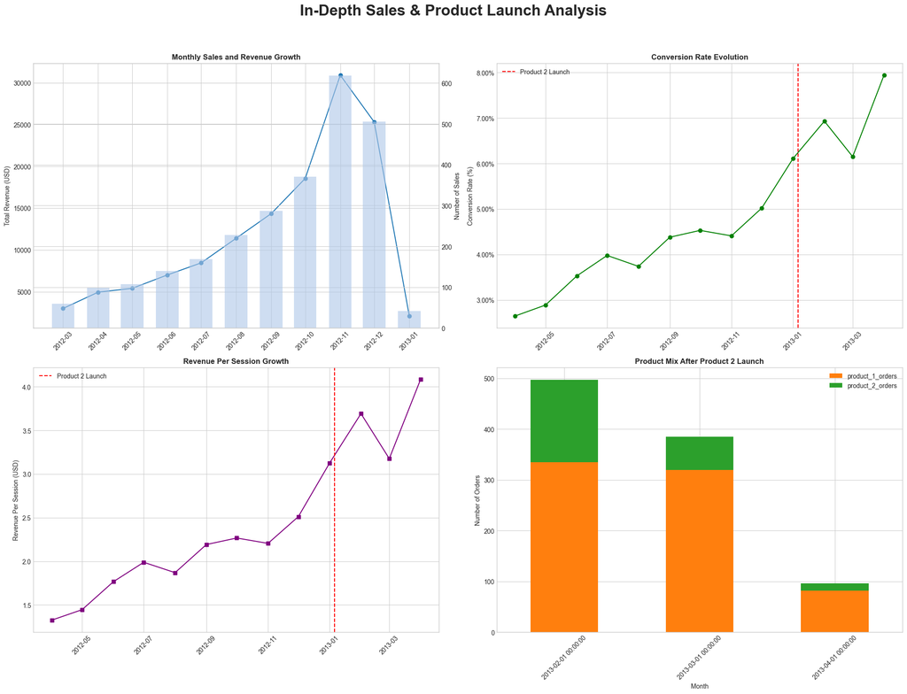

```python
# --- Read Queries for Deeper Sales Analysis ---
with open('04_sales_and_product_analytics/anylising-products-sales-and-products-launches.sql', 'r') as file:
    sql_queries = file.read().split(';')
sql_queries = [q.strip() for q in sql_queries if q.strip()]

df_sales_trends = pd.read_sql(sql_queries[0], engine)
df_monthly_kpis = pd.read_sql(sql_queries[1], engine)

df_sales_trends['date'] = pd.to_datetime(df_sales_trends['yr'].astype(str) + '-' + df_sales_trends['mo'].astype(str))
df_monthly_kpis['date'] = pd.to_datetime(df_monthly_kpis['yr'].astype(str) + '-' + df_monthly_kpis['mo'].astype(str))


# --- Deeper Dive Visualization ---
fig, axes = plt.subplots(2, 2, figsize=(20, 16))
fig.suptitle('In-Depth Sales & Product Launch Analysis', fontsize=24, fontweight='bold')

# 1. Monthly Sales and Revenue Growth
ax1 = axes[0, 0]
ax1.plot(df_sales_trends['date'], df_sales_trends['total_revenue'], label='Total Revenue', marker='o', color='#1f77b4')
ax1_twin = ax1.twinx()
ax1_twin.bar(df_sales_trends['date'], df_sales_trends['sales'], label='Monthly Sales', color='#aec7e8', alpha=0.6, width=20)
ax1.set_title('Monthly Sales and Revenue Growth', fontweight='bold')
ax1.set_ylabel('Total Revenue (USD)')
ax1_twin.set_ylabel('Number of Sales')
ax1.tick_params(axis='x', rotation=45)

# 2. Conversion Rate Evolution (Pre vs. Post Product 2)
product_2_launch_date = pd.to_datetime('2013-01-06')
axes[0, 1].plot(df_monthly_kpis['date'], df_monthly_kpis['conv_rate'] * 100, marker='o', color='g')
axes[0, 1].axvline(product_2_launch_date, color='r', linestyle='--', label='Product 2 Launch')
axes[0, 1].set_title('Conversion Rate Evolution', fontweight='bold')
axes[0, 1].set_ylabel('Conversion Rate (%)')
axes[0, 1].tick_params(axis='x', rotation=45)
axes[0, 1].legend()
axes[0, 1].yaxis.set_major_formatter(plt.FuncFormatter(lambda y, _: f'{y:.2f}%'))

# 3. Revenue Per Session (Pre vs. Post Product 2)
axes[1, 0].plot(df_monthly_kpis['date'], df_monthly_kpis['revenue_per_session'], marker='s', color='purple')
axes[1, 0].axvline(product_2_launch_date, color='r', linestyle='--', label='Product 2 Launch')
axes[1, 0].set_title('Revenue Per Session Growth', fontweight='bold')
axes[1, 0].set_ylabel('Revenue Per Session (USD)')
axes[1, 0].tick_params(axis='x', rotation=45)
axes[1, 0].legend()

# 4. Product Mix Over Time
df_product_mix = df_monthly_kpis[df_monthly_kpis['date'] >= product_2_launch_date]
df_product_mix.plot(x='date', y=['product_1_orders', 'product_2_orders'], kind='bar', stacked=True,
                    ax=axes[1, 1], color=['#ff7f0e', '#2ca02c'])
axes[1, 1].set_title('Product Mix After Product 2 Launch', fontweight='bold')
axes[1, 1].set_xlabel('Month')
axes[1, 1].set_ylabel('Number of Orders')
axes[1, 1].tick_params(axis='x', rotation=45)

plt.tight_layout(rect=[0, 0.03, 1, 0.95])
plt.show()
```

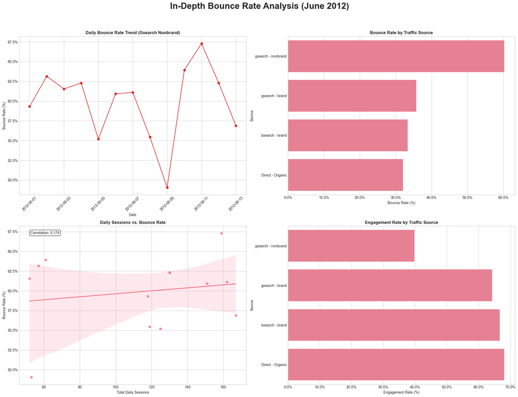

```python
# --- Read Queries for Deeper Bounce Rate Analysis ---

# Query 1: Daily bounce rates for gsearch nonbrand traffic
q1 = """
SELECT
    DATE(website_sessions.created_at) AS date,
    COUNT(DISTINCT website_sessions.website_session_id) AS total_sessions,
    COUNT(DISTINCT CASE WHEN pageview_count = 1 THEN website_sessions.website_session_id ELSE NULL END) AS bounced_sessions,
    (COUNT(DISTINCT CASE WHEN pageview_count = 1 THEN website_sessions.website_session_id ELSE NULL END) / COUNT(DISTINCT website_sessions.website_session_id)) * 100 AS bounce_rate
FROM website_sessions
LEFT JOIN (
    SELECT
        website_session_id,
        COUNT(website_pageview_id) AS pageview_count
    FROM website_pageviews
    GROUP BY website_session_id
) AS session_pageview_counts ON website_sessions.website_session_id = session_pageview_counts.website_session_id
WHERE website_sessions.created_at BETWEEN '2012-06-01' AND '2012-06-14'
  AND website_sessions.utm_source = 'gsearch'
  AND website_sessions.utm_campaign = 'nonbrand'
GROUP BY DATE(website_sessions.created_at)
ORDER BY date;
"""
df_daily_bounce = pd.read_sql(q1, engine)
df_daily_bounce['date'] = pd.to_datetime(df_daily_bounce['date'])

# Query 2: Bounce rates by traffic source
q2 = """
SELECT
    utm_source,
    utm_campaign,
    COUNT(DISTINCT website_sessions.website_session_id) AS total_sessions,
    COUNT(DISTINCT CASE WHEN pageview_count = 1 THEN website_sessions.website_session_id ELSE NULL END) AS bounced_sessions,
    (COUNT(DISTINCT CASE WHEN pageview_count = 1 THEN website_sessions.website_session_id ELSE NULL END) / COUNT(DISTINCT website_sessions.website_session_id)) * 100 AS bounce_rate
FROM website_sessions
LEFT JOIN (
    SELECT
        website_session_id,
        COUNT(website_pageview_id) AS pageview_count
    FROM website_pageviews
    GROUP BY website_session_id
) AS session_pageview_counts ON website_sessions.website_session_id = session_pageview_counts.website_session_id
WHERE website_sessions.created_at BETWEEN '2012-06-01' AND '2012-06-14'
GROUP BY utm_source, utm_campaign
ORDER BY bounce_rate DESC;
"""
df_source_bounce = pd.read_sql(q2, engine)
df_source_bounce['source_label'] = df_source_bounce['utm_source'].fillna('Direct') + ' - ' + df_source_bounce['utm_campaign'].fillna('Organic')


# --- Deeper Dive Visualization ---
fig, axes = plt.subplots(2, 2, figsize=(20, 16))
fig.suptitle('In-Depth Bounce Rate Analysis (June 2012)', fontsize=24, fontweight='bold')

# 1. Daily Bounce Rate Trends
axes[0, 0].plot(df_daily_bounce['date'], df_daily_bounce['bounce_rate'], marker='o', color='#d62728')
axes[0, 0].set_title('Daily Bounce Rate Trend (Gsearch Nonbrand)', fontweight='bold')
axes[0, 0].set_xlabel('Date')
axes[0, 0].set_ylabel('Bounce Rate (%)')
axes[0, 0].tick_params(axis='x', rotation=45)
axes[0, 0].yaxis.set_major_formatter(plt.FuncFormatter(lambda y, _: f'{y:.1f}%'))

# 2. Bounce Rate by Traffic Source
sns.barplot(x='bounce_rate', y='source_label', data=df_source_bounce.sort_values('bounce_rate', ascending=False), ax=axes[0, 1])
axes[0, 1].set_title('Bounce Rate by Traffic Source', fontweight='bold')
axes[0, 1].set_xlabel('Bounce Rate (%)')
axes[0, 1].set_ylabel('Source')
axes[0, 1].xaxis.set_major_formatter(plt.FuncFormatter(lambda x, _: f'{x:.1f}%'))

# 3. Correlation between Daily Sessions and Bounce Rate
sns.regplot(x='total_sessions', y='bounce_rate', data=df_daily_bounce, ax=axes[1, 0])
axes[1, 0].set_title('Daily Sessions vs. Bounce Rate', fontweight='bold')
axes[1, 0].set_xlabel('Total Daily Sessions')
axes[1, 0].set_ylabel('Bounce Rate (%)')
axes[1, 0].yaxis.set_major_formatter(plt.FuncFormatter(lambda y, _: f'{y:.1f}%'))
correlation = df_daily_bounce['total_sessions'].corr(df_daily_bounce['bounce_rate'])
axes[1, 0].text(0.05, 0.95, f'Correlation: {correlation:.3f}', transform=axes[1, 0].transAxes,
                bbox=dict(boxstyle="round,pad=0.3", facecolor="white", alpha=0.8))


# 4. Engagement Rate by Traffic Source
df_source_bounce['engagement_rate'] = 100 - df_source_bounce['bounce_rate']
sns.barplot(x='engagement_rate', y='source_label', data=df_source_bounce.sort_values('engagement_rate', ascending=True), ax=axes[1, 1])
axes[1, 1].set_title('Engagement Rate by Traffic Source', fontweight='bold')
axes[1, 1].set_xlabel('Engagement Rate (%)')
axes[1, 1].set_ylabel('Source')
axes[1, 1].xaxis.set_major_formatter(plt.FuncFormatter(lambda x, _: f'{x:.1f}%'))


plt.tight_layout(rect=[0, 0.03, 1, 0.95])
plt.show()
```

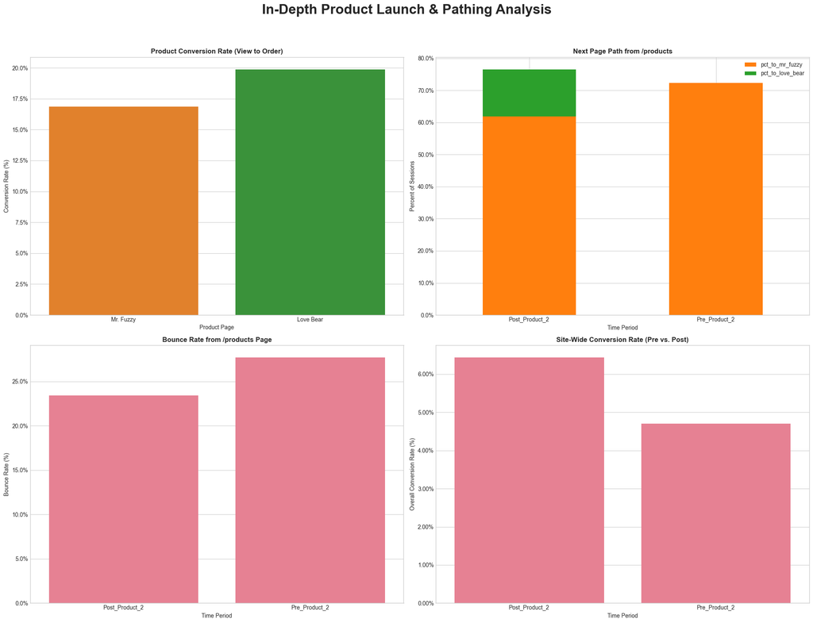

```python
# --- Read Queries for Deeper Product Pathing Analysis ---

# Query 1: Conversion rates for each product
q1 = """
SELECT
    pageview_url,
    COUNT(website_pageviews.website_session_id) AS sessions,
    COUNT(orders.order_id) AS orders,
    COUNT(orders.order_id) / COUNT(website_pageviews.website_session_id) * 100 AS viewed_product_to_order_rate
FROM website_pageviews
LEFT JOIN orders
    ON orders.website_session_id = website_pageviews.website_session_id
WHERE website_pageviews.created_at BETWEEN '2013-02-01' AND '2013-03-01'
  AND website_pageviews.pageview_url IN ('/the-original-mr-fuzzy', '/the-forever-love-bear')
GROUP BY 1;
"""
df_product_conv = pd.read_sql(q1, engine)

# Query 2: Product pathing pre vs. post launch
q2 = """
SELECT
	time_period,
    COUNT(DISTINCT website_session_id) AS sessions,
    COUNT(DISTINCT CASE WHEN next_pv_url IS NOT NULL THEN website_session_id ELSE NULL END) / COUNT(DISTINCT website_session_id) * 100 AS pct_not_bounced,
    COUNT(DISTINCT CASE WHEN next_pv_url = '/the-original-mr-fuzzy' THEN website_session_id ELSE NULL END) / COUNT(DISTINCT website_session_id) * 100 AS pct_to_mr_fuzzy,
    COUNT(DISTINCT CASE WHEN next_pv_url = '/the-forever-love-bear' THEN website_session_id ELSE NULL END) / COUNT(DISTINCT website_session_id) * 100 AS pct_to_love_bear
FROM (
    SELECT
        sessions_with_next_pv.website_session_id,
        sessions_with_next_pv.time_period,
        website_pageviews.pageview_url AS next_pv_url
    FROM (
        SELECT
            products_pageviews.website_session_id,
            products_pageviews.time_period,
            MIN(website_pageviews.website_pageview_id) AS min_next_pv
        FROM (
            SELECT
                ws.website_session_id,
                wp.website_pageview_id,
                CASE WHEN ws.created_at < '2013-01-06' THEN 'Pre_Product_2' ELSE 'Post_Product_2' END AS time_period
            FROM website_sessions ws
            LEFT JOIN website_pageviews wp ON wp.website_session_id = ws.website_session_id
            WHERE ws.created_at BETWEEN '2012-10-06' AND '2013-04-01'
              AND wp.pageview_url = '/products'
        ) AS products_pageviews
        LEFT JOIN website_pageviews ON website_pageviews.website_session_id = products_pageviews.website_session_id
                                   AND website_pageviews.website_pageview_id > products_pageviews.website_pageview_id
        GROUP BY 1, 2
    ) AS sessions_with_next_pv
    LEFT JOIN website_pageviews ON website_pageviews.website_pageview_id = sessions_with_next_pv.min_next_pv
) AS sessions_with_next_pv_url
GROUP BY 1;
"""
df_pathing_agg = pd.read_sql(q2, engine)

# Query 3: Overall business performance pre vs. post launch
q3 = """
SELECT
    CASE WHEN ws.created_at < '2013-01-06' THEN 'Pre_Product_2' ELSE 'Post_Product_2' END AS time_period,
    COUNT(DISTINCT o.order_id) / COUNT(DISTINCT ws.website_session_id) * 100 AS conversion_rate
FROM website_sessions ws
LEFT JOIN orders o ON ws.website_session_id = o.website_session_id
WHERE ws.created_at BETWEEN '2012-10-06' AND '2013-04-01'
GROUP BY 1;
"""
df_business_impact = pd.read_sql(q3, engine)


# --- Deeper Dive Visualization ---
fig, axes = plt.subplots(2, 2, figsize=(20, 16))
fig.suptitle('In-Depth Product Launch & Pathing Analysis', fontsize=24, fontweight='bold')

# 1. Product Conversion Rate Comparison
sns.barplot(x='pageview_url', y='viewed_product_to_order_rate', data=df_product_conv, ax=axes[0, 0], palette=['#ff7f0e', '#2ca02c'])
axes[0, 0].set_title('Product Conversion Rate (View to Order)', fontweight='bold')
axes[0, 0].set_xlabel('Product Page')
axes[0, 0].set_ylabel('Conversion Rate (%)')
axes[0, 0].set_xticklabels(['Mr. Fuzzy', 'Love Bear'])
axes[0, 0].yaxis.set_major_formatter(plt.FuncFormatter(lambda y, _: f'{y:.1f}%'))

# 2. Product Page Navigation Pathing
df_pathing_plot = df_pathing_agg.set_index('time_period')[['pct_to_mr_fuzzy', 'pct_to_love_bear']]
df_pathing_plot.plot(kind='bar', stacked=True, ax=axes[0, 1], color=['#ff7f0e', '#2ca02c'])
axes[0, 1].set_title('Next Page Path from /products', fontweight='bold')
axes[0, 1].set_xlabel('Time Period')
axes[0, 1].set_ylabel('Percent of Sessions')
axes[0, 1].tick_params(axis='x', rotation=0)
axes[0, 1].yaxis.set_major_formatter(plt.FuncFormatter(lambda y, _: f'{y:.1f}%'))

# 3. Engagement from /products page (Bounce Rate)
df_pathing_agg['bounce_rate'] = 100 - df_pathing_agg['pct_not_bounced']
sns.barplot(x='time_period', y='bounce_rate', data=df_pathing_agg, ax=axes[1, 0])
axes[1, 0].set_title('Bounce Rate from /products Page', fontweight='bold')
axes[1, 0].set_xlabel('Time Period')
axes[1, 0].set_ylabel('Bounce Rate (%)')
axes[1, 0].yaxis.set_major_formatter(plt.FuncFormatter(lambda y, _: f'{y:.1f}%'))

# 4. Overall Business Conversion Rate Impact
sns.barplot(x='time_period', y='conversion_rate', data=df_business_impact, ax=axes[1, 1])
axes[1, 1].set_title('Site-Wide Conversion Rate (Pre vs. Post)', fontweight='bold')
axes[1, 1].set_xlabel('Time Period')
axes[1, 1].set_ylabel('Overall Conversion Rate (%)')
axes[1, 1].yaxis.set_major_formatter(plt.FuncFormatter(lambda y, _: f'{y:.2f}%'))


plt.tight_layout(rect=[0, 0.03, 1, 0.95])
plt.show()
```

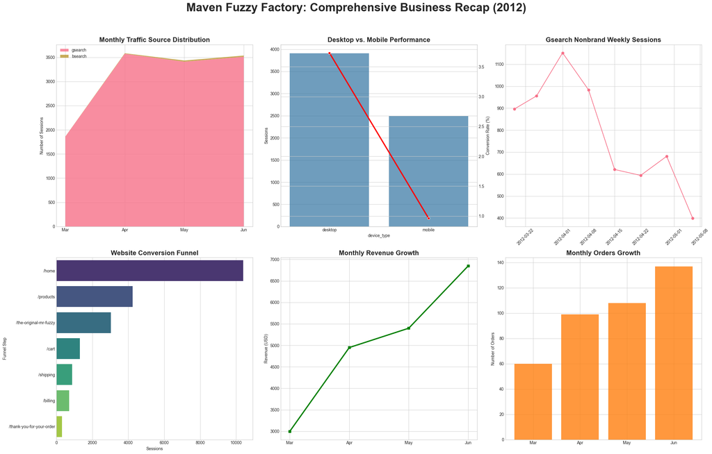

```python
# --- Read All Necessary Recap Queries (with updated Traffic Source Query) ---

# Query 1: Monthly Traffic Source Breakdown (for Stacked Area Chart)
q1 = """
SELECT
    YEAR(created_at) AS yr,
    MONTH(created_at) AS mo,
    utm_source,
    COUNT(website_session_id) AS sessions
FROM website_sessions
WHERE created_at BETWEEN '2012-03-01' AND '2012-06-30'
GROUP BY 1, 2, 3
ORDER BY 1, 2, 3;
"""
df_traffic_sources_monthly = pd.read_sql(q1, engine)
# Pivot the data for the stacked area chart
df_traffic_pivot = df_traffic_sources_monthly.pivot_table(
    index=['yr', 'mo'],
    columns='utm_source',
    values='sessions',
    fill_value=0
).reset_index()
df_traffic_pivot['month_name'] = df_traffic_pivot['mo'].apply(lambda x: pd.to_datetime(str(x), format='%m').strftime('%b'))


# Query 2: Device Performance (Gsearch Nonbrand)
q2 = """
SELECT
    device_type,
    COUNT(DISTINCT ws.website_session_id) AS sessions,
    COUNT(DISTINCT o.order_id) AS orders,
    COUNT(DISTINCT o.order_id) / COUNT(DISTINCT ws.website_session_id) * 100 AS conversion_rate
FROM website_sessions ws
LEFT JOIN orders o ON ws.website_session_id = o.website_session_id
WHERE ws.created_at < '2012-05-11'
  AND ws.utm_source = 'gsearch' AND ws.utm_campaign = 'nonbrand'
GROUP BY 1;
"""
df_device_performance = pd.read_sql(q2, engine)

# Query 3: Weekly Traffic Trends (Gsearch Nonbrand)
q3 = """
SELECT
    MIN(DATE(created_at)) AS week_start_date,
    COUNT(DISTINCT website_session_id) AS sessions
FROM website_sessions
WHERE created_at < '2012-05-10'
  AND utm_source = 'gsearch' AND utm_campaign = 'nonbrand'
GROUP BY YEARWEEK(created_at)
ORDER BY week_start_date;
"""
df_weekly_trends = pd.read_sql(q3, engine)
df_weekly_trends['week_start_date'] = pd.to_datetime(df_weekly_trends['week_start_date'])

# Query 4: Full Conversion Funnel (Gsearch Nonbrand)
q4 = """
-- This is a simplified funnel based on top pages for illustration
SELECT
    pageview_url,
    COUNT(DISTINCT website_session_id) AS sessions
FROM website_pageviews
WHERE created_at < '2012-06-09'
  AND pageview_url IN ('/home', '/products', '/the-original-mr-fuzzy', '/cart', '/shipping', '/billing', '/thank-you-for-your-order')
GROUP BY 1
ORDER BY FIELD(pageview_url, '/home', '/products', '/the-original-mr-fuzzy', '/cart', '/shipping', '/billing', '/thank-you-for-your-order');
"""
df_funnel = pd.read_sql(q4, engine)

# Query 5: Monthly Performance Trends
q5 = """
SELECT
    MONTH(ws.created_at) as mo,
    COUNT(DISTINCT ws.website_session_id) as total_sessions,
    COUNT(DISTINCT o.order_id) as total_orders,
    SUM(o.price_usd) as total_revenue
FROM website_sessions ws
LEFT JOIN orders o ON ws.website_session_id = o.website_session_id
WHERE ws.created_at BETWEEN '2012-03-01' AND '2012-06-30'
GROUP BY 1
ORDER BY 1;
"""
df_monthly = pd.read_sql(q5, engine)
df_monthly['month_name'] = df_monthly['mo'].apply(lambda x: pd.to_datetime(str(x), format='%m').strftime('%b'))

# --- Final Dashboard Visualization (with Stacked Area Chart) ---
fig, axes = plt.subplots(2, 3, figsize=(24, 16))
fig.suptitle('Maven Fuzzy Factory: Comprehensive Business Recap (2012)', fontsize=28, fontweight='bold')

# Plot 1: Monthly Traffic Source Distribution (CHANGED TO STACKED AREA)
axes[0, 0].stackplot(
    df_traffic_pivot['month_name'],
    df_traffic_pivot['gsearch'].fillna(0),
    df_traffic_pivot['bsearch'].fillna(0),
    labels=['gsearch', 'bsearch'],
    alpha=0.8
)
axes[0, 0].set_title('Monthly Traffic Source Distribution', fontweight='bold', fontsize=16)
axes[0, 0].set_ylabel('Number of Sessions')
axes[0, 0].legend(loc='upper left')

# Plot 2: Device Performance Comparison
ax2_twin = axes[0, 1].twinx()
sns.barplot(x='device_type', y='sessions', data=df_device_performance, ax=axes[0, 1], alpha=0.7, color='#1f77b4')
sns.lineplot(x='device_type', y='conversion_rate', data=df_device_performance, ax=ax2_twin, marker='o', color='r', lw=3)
axes[0, 1].set_title('Desktop vs. Mobile Performance', fontweight='bold', fontsize=16)
axes[0, 1].set_ylabel('Sessions')
ax2_twin.set_ylabel('Conversion Rate (%)')

# Plot 3: Weekly Traffic Volume
axes[0, 2].plot(df_weekly_trends['week_start_date'], df_weekly_trends['sessions'], marker='o')
axes[0, 2].set_title('Gsearch Nonbrand Weekly Sessions', fontweight='bold', fontsize=16)
axes[0, 2].tick_params(axis='x', rotation=45)

# Plot 4: Website Conversion Funnel
sns.barplot(x='sessions', y='pageview_url', data=df_funnel, ax=axes[1, 0], palette='viridis')
axes[1, 0].set_title('Website Conversion Funnel', fontweight='bold', fontsize=16)
axes[1, 0].set_xlabel('Sessions')
axes[1, 0].set_ylabel('Funnel Step')

# Plot 5: Monthly Revenue Growth
axes[1, 1].plot(df_monthly['month_name'], df_monthly['total_revenue'], marker='s', color='green', lw=3)
axes[1, 1].set_title('Monthly Revenue Growth', fontweight='bold', fontsize=16)
axes[1, 1].set_ylabel('Revenue (USD)')


# Plot 6: Monthly Orders Growth
axes[1, 2].bar(df_monthly['month_name'], df_monthly['total_orders'], color='#ff7f0e', alpha=0.8)
axes[1, 2].set_title('Monthly Orders Growth', fontweight='bold', fontsize=16)
axes[1, 2].set_ylabel('Number of Orders')

plt.tight_layout(rect=[0, 0.03, 1, 0.95])
plt.show()
```

## second pass!

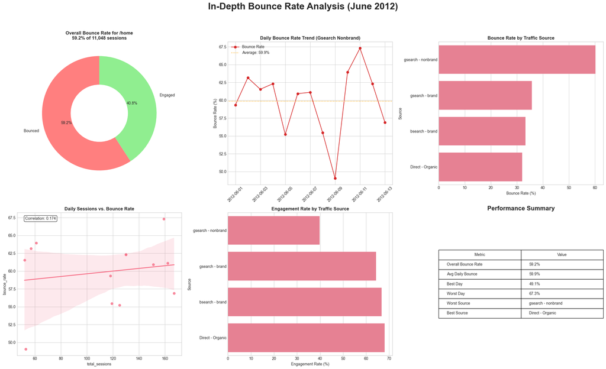

```python
# --- Read Queries for Deeper Bounce Rate Analysis (with corrected GROUP BY clauses) ---

# Query 1: Overall bounce rate for the homepage
q1 = """
SELECT
    sessions_w_lp_url.landing_page,
    COUNT(sessions_w_lp_url.website_session_id) AS sessions_count,
    COUNT(bounced_sessions_only.website_session_id) AS bounced_sessions,
    (COUNT(bounced_sessions_only.website_session_id) / COUNT(sessions_w_lp_url.website_session_id)) * 100 AS bounce_rate
FROM (
    SELECT
        fpd.website_session_id,
        wp.pageview_url AS landing_page
    FROM (
        SELECT
            ws.website_session_id,
            MIN(wp.website_pageview_id) AS min_pv_id
        FROM website_pageviews wp
        LEFT JOIN website_sessions ws ON ws.website_session_id = wp.website_session_id AND ws.created_at < '2012-06-14'
        GROUP BY ws.website_session_id
    ) AS fpd
    LEFT JOIN website_pageviews wp ON wp.website_pageview_id = fpd.min_pv_id
) AS sessions_w_lp_url
LEFT JOIN (
    SELECT
        swlu.website_session_id
    FROM (
        SELECT
            fpd.website_session_id,
            wp.pageview_url AS landing_page
        FROM (
            SELECT
                ws.website_session_id,
                MIN(wp.website_pageview_id) AS min_pv_id
            FROM website_pageviews wp
            LEFT JOIN website_sessions ws ON ws.website_session_id = wp.website_session_id AND ws.created_at < '2012-06-14'
            GROUP BY ws.website_session_id
        ) AS fpd
        LEFT JOIN website_pageviews wp ON wp.website_pageview_id = fpd.min_pv_id
    ) AS swlu
    LEFT JOIN website_pageviews wp ON wp.website_session_id = swlu.website_session_id
    GROUP BY swlu.website_session_id, swlu.landing_page
    HAVING COUNT(wp.website_pageview_id) = 1
) AS bounced_sessions_only ON sessions_w_lp_url.website_session_id = bounced_sessions_only.website_session_id
WHERE sessions_w_lp_url.landing_page = '/home'
GROUP BY sessions_w_lp_url.landing_page;
"""
df_overall_bounce = pd.read_sql(q1, engine)

# Query 2: Daily bounce rates for gsearch nonbrand traffic
q2 = """
SELECT
    DATE(ws.created_at) AS date,
    COUNT(DISTINCT ws.website_session_id) AS total_sessions,
    (COUNT(DISTINCT CASE WHEN pageview_count = 1 THEN ws.website_session_id ELSE NULL END) / COUNT(DISTINCT ws.website_session_id)) * 100 AS bounce_rate
FROM website_sessions ws
LEFT JOIN (
    SELECT website_session_id, COUNT(website_pageview_id) AS pageview_count FROM website_pageviews GROUP BY website_session_id
) AS session_counts ON ws.website_session_id = session_counts.website_session_id
WHERE ws.created_at BETWEEN '2012-06-01' AND '2012-06-14' AND ws.utm_source = 'gsearch' AND ws.utm_campaign = 'nonbrand'
GROUP BY DATE(ws.created_at) ORDER BY date;
"""
df_daily_bounce = pd.read_sql(q2, engine)
df_daily_bounce['date'] = pd.to_datetime(df_daily_bounce['date'])

# Query 3: Bounce rates by traffic source
q3 = """
SELECT
    utm_source, utm_campaign,
    COUNT(DISTINCT ws.website_session_id) AS total_sessions,
    (COUNT(DISTINCT CASE WHEN pageview_count = 1 THEN ws.website_session_id ELSE NULL END) / COUNT(DISTINCT ws.website_session_id)) * 100 AS bounce_rate
FROM website_sessions ws
LEFT JOIN (
    SELECT website_session_id, COUNT(website_pageview_id) AS pageview_count FROM website_pageviews GROUP BY website_session_id
) AS session_counts ON ws.website_session_id = session_counts.website_session_id
WHERE ws.created_at BETWEEN '2012-06-01' AND '2012-06-14'
GROUP BY utm_source, utm_campaign ORDER BY bounce_rate DESC;
"""
df_source_bounce = pd.read_sql(q3, engine)
df_source_bounce['source_label'] = df_source_bounce['utm_source'].fillna('Direct') + ' - ' + df_source_bounce['utm_campaign'].fillna('Organic')

# --- Comprehensive Visualization (recreating your script's dashboard) ---
fig, axes = plt.subplots(2, 3, figsize=(22, 14))
fig.suptitle('In-Depth Bounce Rate Analysis (June 2012)', fontsize=24, fontweight='bold')

# 1. Overall Bounce Rate Summary
ax1 = axes[0, 0]
sizes = [df_overall_bounce['bounced_sessions'].iloc[0], df_overall_bounce['sessions_count'].iloc[0] - df_overall_bounce['bounced_sessions'].iloc[0]]
ax1.pie(sizes, labels=['Bounced', 'Engaged'], colors=['#ff7f7f', '#90ee90'], autopct='%1.1f%%', startangle=90, wedgeprops=dict(width=0.5))
ax1.set_title(f'Overall Bounce Rate for /home\n{df_overall_bounce["bounce_rate"].iloc[0]:.1f}% of {df_overall_bounce["sessions_count"].iloc[0]:,} sessions', fontweight='bold')

# 2. Daily Bounce Rate Trend
ax2 = axes[0, 1]
ax2.plot(df_daily_bounce['date'], df_daily_bounce['bounce_rate'], marker='o', color='#d62728', label='Bounce Rate')
ax2.set_title('Daily Bounce Rate Trend (Gsearch Nonbrand)', fontweight='bold')
ax2.set_ylabel('Bounce Rate (%)')
ax2.tick_params(axis='x', rotation=45)
avg_bounce = df_daily_bounce['bounce_rate'].mean()
ax2.axhline(y=avg_bounce, color='orange', linestyle=':', label=f'Average: {avg_bounce:.1f}%')
ax2.legend()

# 3. Traffic Source Comparison
ax3 = axes[0, 2]
sns.barplot(x='bounce_rate', y='source_label', data=df_source_bounce, ax=ax3)
ax3.set_title('Bounce Rate by Traffic Source', fontweight='bold')
ax3.set_xlabel('Bounce Rate (%)')
ax3.set_ylabel('Source')

# 4. Daily Sessions vs Bounce Rate Correlation
ax4 = axes[1, 0]
sns.regplot(x='total_sessions', y='bounce_rate', data=df_daily_bounce, ax=ax4)
ax4.set_title('Daily Sessions vs. Bounce Rate', fontweight='bold')
correlation = df_daily_bounce['total_sessions'].corr(df_daily_bounce['bounce_rate'])
ax4.text(0.05, 0.95, f'Correlation: {correlation:.3f}', transform=ax4.transAxes, bbox=dict(boxstyle="round", facecolor="white", alpha=0.8))

# 5. Engagement Rate Comparison
ax5 = axes[1, 1]
df_source_bounce['engagement_rate'] = 100 - df_source_bounce['bounce_rate']
sns.barplot(x='engagement_rate', y='source_label', data=df_source_bounce.sort_values('engagement_rate'), ax=ax5)
ax5.set_title('Engagement Rate by Traffic Source', fontweight='bold')
ax5.set_xlabel('Engagement Rate (%)')
ax5.set_ylabel('Source')

# 6. Performance Metrics Summary Table
ax6 = axes[1, 2]
ax6.axis('off')
summary_data = [
    ['Overall Bounce Rate', f"{df_overall_bounce['bounce_rate'].iloc[0]:.1f}%"],
    ['Avg Daily Bounce', f"{avg_bounce:.1f}%"],
    ['Best Day', f"{df_daily_bounce['bounce_rate'].min():.1f}%"],
    ['Worst Day', f"{df_daily_bounce['bounce_rate'].max():.1f}%"],
    ['Worst Source', df_source_bounce.loc[df_source_bounce['bounce_rate'].idxmax()]['source_label']],
    ['Best Source', df_source_bounce.loc[df_source_bounce['bounce_rate'].idxmin()]['source_label']]
]
table = ax6.table(cellText=summary_data, colLabels=['Metric', 'Value'], loc='center', cellLoc='left')
table.scale(1, 2)
ax6.set_title('Performance Summary', fontweight='bold', fontsize=16)

plt.tight_layout(rect=[0, 0.03, 1, 0.95])
plt.show()
```

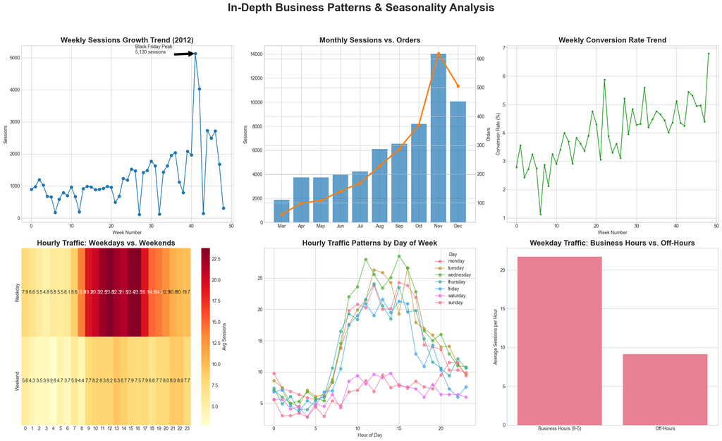

```python
# --- Read Queries for Deeper Seasonality Analysis ---
with open('01_traffic_and_channel_analysis/analysing-business-patterns-and-seasonality.sql', 'r') as file:
    sql_queries = file.read().split(';')
sql_queries = [q.strip() for q in sql_queries if q.strip()]

# Query 1: Weekly sessions and orders
df_weekly = pd.read_sql(sql_queries[0], engine)

# Query 2: Hourly patterns by day of the week (CORRECTED to use the 4th query, index 3)
df_hourly_raw = pd.read_sql(sql_queries[3], engine)

# --- Data Processing & Column Renaming ---
# Rename columns to match the original visualization script's expectations
df_hourly = df_hourly_raw.rename(columns={
    'hr': 'hour', 'mon_avg': 'monday', 'tue_avg': 'tuesday', 'wed_avg': 'wednesday',
    'thu_avg': 'thursday', 'fri_avg': 'friday', 'sat_avg': 'saturday', 'sun_avg': 'sunday'
})

df_weekly['conversion_rate'] = (df_weekly['orders'] / df_weekly['sessions']) * 100
monthly_agg = df_weekly.groupby('mo').agg({'sessions': 'sum', 'orders': 'sum'}).reset_index()
monthly_agg['month_name'] = monthly_agg['mo'].apply(lambda x: pd.to_datetime(str(x), format='%m').strftime('%b'))


# --- Comprehensive Visualization (recreating your script's dashboard) ---
#fig, axes = plt.subplots(3, 2, figsize=(20, 24))
fig, axes = plt.subplots(2, 3, figsize=(22, 14))
fig.suptitle('In-Depth Business Patterns & Seasonality Analysis', fontsize=24, fontweight='bold')

# 1. Weekly Sessions Growth Trend
axes[0, 0].plot(df_weekly.index, df_weekly['sessions'], marker='o', color='#1f77b4')
axes[0, 0].set_title('Weekly Sessions Growth Trend (2012)', fontweight='bold', fontsize=16)
axes[0, 0].set_xlabel('Week Number')
axes[0, 0].set_ylabel('Sessions')
max_idx = df_weekly['sessions'].idxmax()
axes[0, 0].annotate(f"Black Friday Peak\n{df_weekly.loc[max_idx, 'sessions']:,} sessions",
                   xy=(max_idx, df_weekly.loc[max_idx, 'sessions']),
                   xytext=(max_idx - 15, df_weekly.loc[max_idx, 'sessions']),
                   arrowprops=dict(facecolor='black', shrink=0.05))

# 2. Monthly Sessions & Orders
ax2_twin = axes[0, 1].twinx()
axes[0, 1].bar(monthly_agg['month_name'], monthly_agg['sessions'], color='#1f77b4', alpha=0.7, label='Sessions')
ax2_twin.plot(monthly_agg['month_name'], monthly_agg['orders'], color='#ff7f0e', marker='o', lw=3, label='Orders')
axes[0, 1].set_title('Monthly Sessions vs. Orders', fontweight='bold', fontsize=16)
axes[0, 1].set_ylabel('Sessions')
ax2_twin.set_ylabel('Orders')

# 3. Weekly Conversion Rate Trend
axes[0, 2].plot(df_weekly.index, df_weekly['conversion_rate'], marker='.', color='#2ca02c')
axes[0, 2].set_title('Weekly Conversion Rate Trend', fontweight='bold', fontsize=16)
axes[0, 2].set_ylabel('Conversion Rate (%)')
axes[0, 2].set_xlabel('Week Number')

# 4. Hourly Heatmap (Weekdays vs Weekends)
weekdays = ['monday', 'tuesday', 'wednesday', 'thursday', 'friday']
weekends = ['saturday', 'sunday']
heatmap_data = pd.DataFrame({
    'Weekday': df_hourly[weekdays].mean(axis=1),
    'Weekend': df_hourly[weekends].mean(axis=1)
})
sns.heatmap(heatmap_data.T, annot=True, fmt='.1f', cmap='YlOrRd', ax=axes[1, 0], cbar_kws={'label': 'Avg Sessions'})
axes[1, 0].set_title('Hourly Traffic: Weekdays vs. Weekends', fontweight='bold', fontsize=16)

# 5. Daily Pattern Comparison
df_hourly.plot(x='hour', y=weekdays + weekends, ax=axes[1, 1], marker='o', alpha=0.7)
axes[1, 1].set_title('Hourly Traffic Patterns by Day of Week', fontweight='bold', fontsize=16)
axes[1, 1].set_xlabel('Hour of Day')
axes[1, 1].legend(title='Day')

# 6. Business Hours Analysis
business_hours = list(range(9, 18))
business_avg = df_hourly.loc[df_hourly['hour'].isin(business_hours), weekdays].mean().mean()
off_hours_avg = df_hourly.loc[~df_hourly['hour'].isin(business_hours), weekdays].mean().mean()
sns.barplot(x=['Business Hours (9-5)', 'Off-Hours'], y=[business_avg, off_hours_avg], ax=axes[1, 2])
axes[1, 2].set_title('Weekday Traffic: Business Hours vs. Off-Hours', fontweight='bold', fontsize=16)
axes[1, 2].set_ylabel('Average Sessions per Hour')

plt.tight_layout(rect=[0, 0.03, 1, 0.95])
plt.show()
```

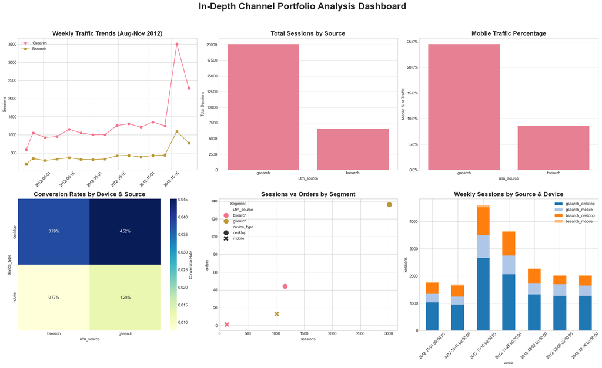

```python
# --- Read Queries for Deeper Channel Portfolio Analysis ---
with open('01_traffic_and_channel_analysis/channel-portfolio-analysis.sql', 'r') as file:
    sql_queries = file.read().split(';')
sql_queries = [q.strip() for q in sql_queries if q.strip()]

# --- Execute All 4 Queries ---
df_weekly = pd.read_sql(sql_queries[0], engine)
df_mobile = pd.read_sql(sql_queries[1], engine)
df_conversion = pd.read_sql(sql_queries[2], engine)
df_detailed_raw = pd.read_sql(sql_queries[3], engine)

# --- Data Processing & Column Renaming (THE FIX) ---
df_weekly['week_start'] = pd.to_datetime(df_weekly['min(date(created_at))'])

# Rename columns to match the original visualization script's expectations
df_detailed = df_detailed_raw.rename(columns={
    'wk': 'week',
    'gsearch_desk_session': 'gsearch_desktop',
    'gsearch_mob_session': 'gsearch_mobile',
    'bsearch_desk_session': 'bsearch_desktop',
    'bsearch_mob_session': 'bsearch_mobile'
})
df_detailed['week'] = pd.to_datetime(df_detailed['week'])


# --- Comprehensive Visualization (recreating your script's dashboard) ---
fig, axes = plt.subplots(2, 3, figsize=(22, 14))
fig.suptitle('In-Depth Channel Portfolio Analysis Dashboard', fontsize=24, fontweight='bold')

# 1. Weekly Traffic Trends
ax1 = axes[0, 0]
ax1.plot(df_weekly['week_start'], df_weekly['gsearch_sessions'], marker='o', label='Gsearch')
ax1.plot(df_weekly['week_start'], df_weekly['bsearch_sessions'], marker='s', label='Bsearch')
ax1.set_title('Weekly Traffic Trends (Aug-Nov 2012)', fontweight='bold', fontsize=16)
ax1.set_ylabel('Sessions')
ax1.tick_params(axis='x', rotation=45)
ax1.legend()

# 2. Traffic Volume Comparison
ax2 = axes[0, 1]
sns.barplot(x='utm_source', y='sessions', data=df_mobile, ax=ax2)
ax2.set_title('Total Sessions by Source', fontweight='bold', fontsize=16)
ax2.set_ylabel('Total Sessions')

# 3. Mobile vs Desktop Split
ax3 = axes[0, 2]
df_mobile['pct_mobile_fmt'] = df_mobile['pct_mobile'] * 100
sns.barplot(x='utm_source', y='pct_mobile_fmt', data=df_mobile, ax=ax3)
ax3.set_title('Mobile Traffic Percentage', fontweight='bold', fontsize=16)
ax3.set_ylabel('Mobile % of Traffic')
ax3.yaxis.set_major_formatter(plt.FuncFormatter(lambda y, _: f'{y:.1f}%'))

# 4. Conversion Rate Heatmap
ax4 = axes[1, 0]
conv_pivot = df_conversion.pivot(index='device_type', columns='utm_source', values='conv_rate')
sns.heatmap(conv_pivot, annot=True, fmt='.2%', cmap='YlGnBu', ax=ax4, cbar_kws={'label': 'Conversion Rate'})
ax4.set_title('Conversion Rates by Device & Source', fontweight='bold', fontsize=16)

# 5. Sessions vs Orders Scatter
ax5 = axes[1, 1]
sns.scatterplot(data=df_conversion, x='sessions', y='orders', hue='utm_source', style='device_type', s=200, ax=ax5)
ax5.set_title('Sessions vs Orders by Segment', fontweight='bold', fontsize=16)
ax5.legend(title='Segment')

# 6. Detailed Weekly Breakdown (Stacked Bar)
ax6 = axes[1, 2]
df_detailed.plot(x='week', y=['gsearch_desktop', 'gsearch_mobile', 'bsearch_desktop', 'bsearch_mobile'],
                 kind='bar', stacked=True, ax=ax6,
                 color=['#1f77b4', '#aec7e8', '#ff7f0e', '#ffbb78'])
ax6.set_title('Weekly Sessions by Source & Device', fontweight='bold', fontsize=16)
ax6.set_ylabel('Sessions')
ax6.tick_params(axis='x', rotation=45)

plt.tight_layout(rect=[0, 0.03, 1, 0.95])
plt.show()
```

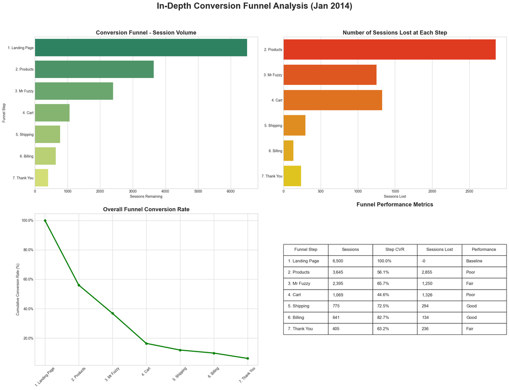

```python
# --- Read and Construct the Corrected Sequential Funnel Query ---
# This query now correctly builds a sequential funnel, ensuring session counts only decrease.
sequential_funnel_query = """
WITH session_flags AS (
    SELECT
        ws.website_session_id,
        MAX(CASE WHEN pageview_url = '/lander-2' THEN 1 ELSE 0 END) AS to_lander,
        MAX(CASE WHEN pageview_url = '/products' THEN 1 ELSE 0 END) AS to_products,
        MAX(CASE WHEN pageview_url = '/the-original-mr-fuzzy' THEN 1 ELSE 0 END) AS to_mrfuzzy,
        MAX(CASE WHEN pageview_url = '/cart' THEN 1 ELSE 0 END) AS to_cart,
        MAX(CASE WHEN pageview_url = '/shipping' THEN 1 ELSE 0 END) AS to_shipping,
        MAX(CASE WHEN pageview_url = '/billing-2' THEN 1 ELSE 0 END) AS to_billing,
        MAX(CASE WHEN pageview_url = '/thank-you-for-your-order' THEN 1 ELSE 0 END) AS to_thankyou
    FROM website_sessions ws
    LEFT JOIN website_pageviews wp ON ws.website_session_id = wp.website_session_id
    WHERE ws.created_at BETWEEN '2014-01-01' AND '2014-02-01'
    GROUP BY ws.website_session_id
)
SELECT '1. Landing Page' AS step_name, COUNT(website_session_id) AS sessions FROM session_flags WHERE to_lander = 1
UNION
SELECT '2. Products', COUNT(website_session_id) FROM session_flags WHERE to_lander = 1 AND to_products = 1
UNION
SELECT '3. Mr Fuzzy', COUNT(website_session_id) FROM session_flags WHERE to_lander = 1 AND to_products = 1 AND to_mrfuzzy = 1
UNION
SELECT '4. Cart', COUNT(website_session_id) FROM session_flags WHERE to_lander = 1 AND to_products = 1 AND to_mrfuzzy = 1 AND to_cart = 1
UNION
SELECT '5. Shipping', COUNT(website_session_id) FROM session_flags WHERE to_lander = 1 AND to_products = 1 AND to_mrfuzzy = 1 AND to_cart = 1 AND to_shipping = 1
UNION
SELECT '6. Billing', COUNT(website_session_id) FROM session_flags WHERE to_lander = 1 AND to_products = 1 AND to_mrfuzzy = 1 AND to_cart = 1 AND to_shipping = 1 AND to_billing = 1
UNION
SELECT '7. Thank You', COUNT(website_session_id) FROM session_flags WHERE to_lander = 1 AND to_products = 1 AND to_mrfuzzy = 1 AND to_cart = 1 AND to_shipping = 1 AND to_billing = 1 AND to_thankyou = 1;
"""
df_funnel = pd.read_sql(sequential_funnel_query, engine)

# --- Data Processing for Visualization ---
df_funnel['sessions_lost'] = -df_funnel['sessions'].diff().fillna(0)
df_funnel['cumulative_conversion'] = (df_funnel['sessions'] / df_funnel['sessions'].iloc[0]) * 100


# --- Simplified and Corrected Visualization ---
fig, axes = plt.subplots(2, 2, figsize=(20, 16))
fig.suptitle('In-Depth Conversion Funnel Analysis (Jan 2014)', fontsize=24, fontweight='bold')

# 1. Classic Funnel Visualization
ax1 = axes[0, 0]
sns.barplot(x='sessions', y='step_name', data=df_funnel, ax=ax1, palette='summer')
ax1.set_title('Conversion Funnel - Session Volume', fontweight='bold', fontsize=16)
ax1.set_xlabel('Sessions Remaining')
ax1.set_ylabel('Funnel Step')

# 2. Where Are We Losing Users? (Session Dropoff)
ax2 = axes[0, 1]
sns.barplot(x='sessions_lost', y='step_name', data=df_funnel[df_funnel.index > 0], ax=ax2, palette='autumn')
ax2.set_title('Number of Sessions Lost at Each Step', fontweight='bold', fontsize=16)
ax2.set_xlabel('Sessions Lost')
ax2.set_ylabel('')

# 3. Overall Funnel Efficiency (Cumulative Conversion)
ax3 = axes[1, 0]
ax3.plot(df_funnel['step_name'], df_funnel['cumulative_conversion'], marker='o', lw=3, color='green')
ax3.set_title('Overall Funnel Conversion Rate', fontweight='bold', fontsize=16)
ax3.set_ylabel('Cumulative Conversion Rate (%)')
ax3.tick_params(axis='x', rotation=45)
ax3.yaxis.set_major_formatter(plt.FuncFormatter(lambda y, _: f'{y:.1f}%'))

# 4. Funnel Performance Metrics Table
ax4 = axes[1, 1]
ax4.axis('off')
df_funnel['step_conversion'] = df_funnel['sessions'] / df_funnel['sessions'].shift(1)
metrics_data = []
for i, row in df_funnel.iterrows():
    performance = "Good" if row['step_conversion'] >= 0.7 else "Fair" if row['step_conversion'] >= 0.6 else "Poor"
    if i == 0: performance = "Baseline"
    metrics_data.append([
        row['step_name'], f"{row['sessions']:,}", f"{row['step_conversion']*100:.1f}%" if i > 0 else "100.0%",
        f"{row['sessions_lost']:,.0f}", performance
    ])
table = ax4.table(cellText=metrics_data,
                  colLabels=['Funnel Step', 'Sessions', 'Step CVR', 'Sessions Lost', 'Performance'],
                  loc='center', cellLoc='left')
table.auto_set_font_size(False)
table.set_fontsize(12)
table.scale(1, 2.5)
ax4.set_title('Funnel Performance Metrics', fontweight='bold', fontsize=16, pad=20)

plt.tight_layout(rect=[0, 0.03, 1, 0.95])
plt.show()
```

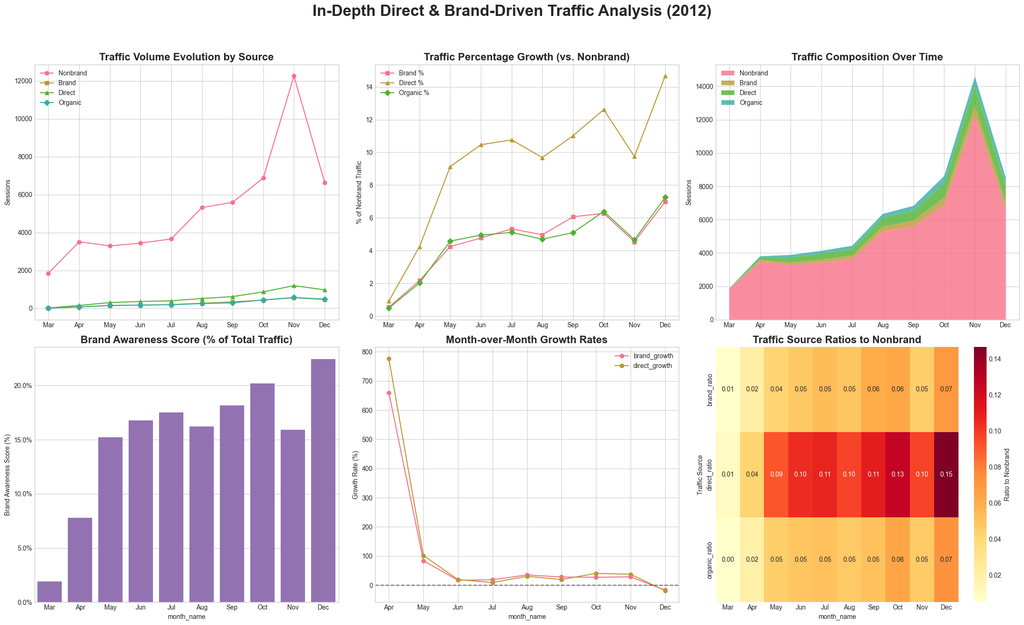

```python
# --- Read Query for Direct & Brand Traffic Analysis ---
with open('01_traffic_and_channel_analysis/analysing-direct-brand-driven-traffic.sql', 'r') as file:
    query = file.read()
df_brand_traffic_raw = pd.read_sql(query, engine)

# --- Data Processing & Column Renaming (THE FIX) ---
# Rename the columns from the SQL query to match what the plotting code expects
df_brand_traffic = df_brand_traffic_raw.rename(columns={
    'p1': 'brand_pct',
    'p2': 'direct_pct',
    'p3': 'organic_pct'
})

df_brand_traffic['month_name'] = df_brand_traffic['mo'].apply(lambda x: pd.to_datetime(str(x), format='%m').strftime('%b'))
df_brand_traffic['total_traffic'] = df_brand_traffic['nonbrand'] + df_brand_traffic['brand'] + df_brand_traffic['direct'] + df_brand_traffic['organic']
df_brand_traffic['brand_awareness_score'] = (df_brand_traffic['brand'] + df_brand_traffic['direct'] + df_brand_traffic['organic']) / df_brand_traffic['total_traffic'] * 100


# --- Comprehensive Visualization ---
fig, axes = plt.subplots(2, 3, figsize=(22, 14))
fig.suptitle('In-Depth Direct & Brand-Driven Traffic Analysis (2012)', fontsize=24, fontweight='bold')

# 1. Traffic Volume Evolution
ax1 = axes[0, 0]
ax1.plot(df_brand_traffic['month_name'], df_brand_traffic['nonbrand'], marker='o', label='Nonbrand')
ax1.plot(df_brand_traffic['month_name'], df_brand_traffic['brand'], marker='s', label='Brand')
ax1.plot(df_brand_traffic['month_name'], df_brand_traffic['direct'], marker='^', label='Direct')
ax1.plot(df_brand_traffic['month_name'], df_brand_traffic['organic'], marker='D', label='Organic')
ax1.set_title('Traffic Volume Evolution by Source', fontweight='bold', fontsize=16)
ax1.set_ylabel('Sessions')
ax1.legend()

# 2. Percentage Growth Trends (vs. Nonbrand)
ax2 = axes[0, 1]
ax2.plot(df_brand_traffic['month_name'], df_brand_traffic['brand_pct'], marker='s', label='Brand %')
ax2.plot(df_brand_traffic['month_name'], df_brand_traffic['direct_pct'], marker='^', label='Direct %')
ax2.plot(df_brand_traffic['month_name'], df_brand_traffic['organic_pct'], marker='D', label='Organic %')
ax2.set_title('Traffic Percentage Growth (vs. Nonbrand)', fontweight='bold', fontsize=16)
ax2.set_ylabel('% of Nonbrand Traffic')
ax2.legend()

# 3. Stacked Area Chart - Traffic Composition
ax3 = axes[0, 2]
ax3.stackplot(df_brand_traffic['month_name'], df_brand_traffic['nonbrand'], df_brand_traffic['brand'], df_brand_traffic['direct'], df_brand_traffic['organic'],
              labels=['Nonbrand', 'Brand', 'Direct', 'Organic'], alpha=0.8)
ax3.set_title('Traffic Composition Over Time', fontweight='bold', fontsize=16)
ax3.set_ylabel('Sessions')
ax3.legend(loc='upper left')

# 4. Brand Awareness Score
ax4 = axes[1, 0]
sns.barplot(x='month_name', y='brand_awareness_score', data=df_brand_traffic, ax=ax4, color='#9467bd')
ax4.set_title('Brand Awareness Score (% of Total Traffic)', fontweight='bold', fontsize=16)
ax4.set_ylabel('Brand Awareness Score (%)')
ax4.yaxis.set_major_formatter(plt.FuncFormatter(lambda y, _: f'{y:.1f}%'))

# 5. Month-over-Month Growth Rates
ax5 = axes[1, 1]
df_brand_traffic['brand_growth'] = df_brand_traffic['brand'].pct_change() * 100
df_brand_traffic['direct_growth'] = df_brand_traffic['direct'].pct_change() * 100
df_brand_traffic.plot(x='month_name', y=['brand_growth', 'direct_growth'], ax=ax5, marker='o')
ax5.axhline(y=0, color='black', linestyle='--', alpha=0.5)
ax5.set_title('Month-over-Month Growth Rates', fontweight='bold', fontsize=16)
ax5.set_ylabel('Growth Rate (%)')
ax5.legend()

# 6. Traffic Source Ratios Heatmap
ax6 = axes[1, 2]
df_brand_traffic['brand_ratio'] = df_brand_traffic['brand'] / df_brand_traffic['nonbrand']
df_brand_traffic['direct_ratio'] = df_brand_traffic['direct'] / df_brand_traffic['nonbrand']
df_brand_traffic['organic_ratio'] = df_brand_traffic['organic'] / df_brand_traffic['nonbrand']
ratio_data = df_brand_traffic.set_index('month_name')[['brand_ratio', 'direct_ratio', 'organic_ratio']].T
sns.heatmap(ratio_data, annot=True, fmt='.2f', cmap='YlOrRd', ax=ax6, cbar_kws={'label': 'Ratio to Nonbrand'})
ax6.set_title('Traffic Source Ratios to Nonbrand', fontweight='bold', fontsize=16)
ax6.set_ylabel('Traffic Source')

plt.tight_layout(rect=[0, 0.03, 1, 0.95])
plt.show()
```

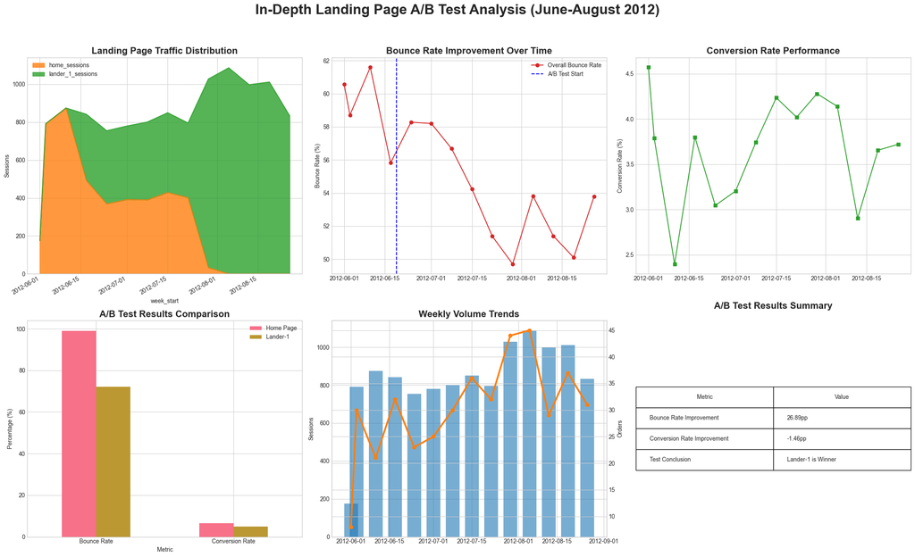

```python
# --- Read and Construct Query for Landing Page A/B Test Analysis ---
# This query gathers weekly data on sessions, bounces, orders, and traffic split for the test period.
landing_page_query = """
WITH session_details AS (
    SELECT
        ws.website_session_id,
        ws.created_at,
        MIN(wp.website_pageview_id) AS first_pageview_id,
        COUNT(wp.website_pageview_id) AS pageview_count,
        MAX(CASE WHEN o.order_id IS NOT NULL THEN 1 ELSE 0 END) AS has_order
    FROM website_sessions ws
    LEFT JOIN website_pageviews wp ON ws.website_session_id = wp.website_session_id
    LEFT JOIN orders o ON ws.website_session_id = o.website_session_id
    WHERE ws.created_at BETWEEN '2012-06-01' AND '2012-08-31'
      AND ws.utm_source = 'gsearch' AND ws.utm_campaign = 'nonbrand'
    GROUP BY ws.website_session_id
),
sessions_with_landing_page AS (
    SELECT
        sd.website_session_id,
        sd.created_at,
        sd.pageview_count,
        sd.has_order,
        wp.pageview_url AS landing_page
    FROM session_details sd
    LEFT JOIN website_pageviews wp ON sd.first_pageview_id = wp.website_pageview_id
)
SELECT
    MIN(DATE(created_at)) AS week_start,
    COUNT(website_session_id) AS total_sessions,
    COUNT(CASE WHEN pageview_count = 1 THEN website_session_id ELSE NULL END) AS bounced_sessions,
    COUNT(CASE WHEN landing_page = '/home' THEN website_session_id ELSE NULL END) AS home_sessions,
    COUNT(CASE WHEN landing_page = '/lander-1' THEN website_session_id ELSE NULL END) AS lander_1_sessions,
    SUM(has_order) AS orders
FROM sessions_with_landing_page
GROUP BY YEARWEEK(created_at)
ORDER BY week_start;
"""
df = pd.read_sql(landing_page_query, engine)

# --- Data Processing for Visualization ---
df['week_start'] = pd.to_datetime(df['week_start'])
df['bounce_rate'] = (df['bounced_sessions'] / df['total_sessions']) * 100
df['conversion_rate'] = (df['orders'] / df['total_sessions']) * 100

# --- Comprehensive Visualization ---
fig, axes = plt.subplots(2, 3, figsize=(22, 14))
fig.suptitle('In-Depth Landing Page A/B Test Analysis (June-August 2012)', fontsize=24, fontweight='bold')

# 1. Landing Page Traffic Distribution
ax1 = axes[0, 0]
df.plot(x='week_start', y=['home_sessions', 'lander_1_sessions'], kind='area', stacked=True, ax=ax1,
        color=['#ff7f0e', '#2ca02c'], alpha=0.8)
ax1.set_title('Landing Page Traffic Distribution', fontweight='bold', fontsize=16)
ax1.set_ylabel('Sessions')

# 2. Bounce Rate Trend
ax2 = axes[0, 1]
ax2.plot(df['week_start'], df['bounce_rate'], marker='o', color='#d62728', label='Overall Bounce Rate')
ax2.set_title('Bounce Rate Improvement Over Time', fontweight='bold', fontsize=16)
ax2.set_ylabel('Bounce Rate (%)')
ax2.axvline(pd.to_datetime('2012-06-19'), color='blue', linestyle='--', label='A/B Test Start')
ax2.legend()

# 3. Conversion Rate Performance
ax3 = axes[0, 2]
ax3.plot(df['week_start'], df['conversion_rate'], marker='s', color='#2ca02c', label='Conversion Rate')
ax3.set_title('Conversion Rate Performance', fontweight='bold', fontsize=16)
ax3.set_ylabel('Conversion Rate (%)')

# 4. A/B Test Performance Comparison
ax4 = axes[1, 0]
home_total_sessions = df['home_sessions'].sum()
lander_total_sessions = df['lander_1_sessions'].sum()
home_bounced = df[df['home_sessions'] > 0]['bounced_sessions'].sum()
lander_bounced = df[df['lander_1_sessions'] > 0]['bounced_sessions'].sum()
home_orders = df[df['home_sessions'] > 0]['orders'].sum()
lander_orders = df[df['lander_1_sessions'] > 0]['orders'].sum()

home_bounce_rate = (home_bounced / home_total_sessions) * 100 if home_total_sessions else 0
lander_bounce_rate = (lander_bounced / lander_total_sessions) * 100 if lander_total_sessions else 0
home_conv_rate = (home_orders / home_total_sessions) * 100 if home_total_sessions else 0
lander_conv_rate = (lander_orders / lander_total_sessions) * 100 if lander_total_sessions else 0

comparison_data = pd.DataFrame({
    'Metric': ['Bounce Rate', 'Conversion Rate'],
    'Home Page': [home_bounce_rate, home_conv_rate],
    'Lander-1': [lander_bounce_rate, lander_conv_rate]
}).set_index('Metric')
comparison_data.plot(kind='bar', ax=ax4)
ax4.set_title('A/B Test Results Comparison', fontweight='bold', fontsize=16)
ax4.set_ylabel('Percentage (%)')
ax4.tick_params(axis='x', rotation=0)

# 5. Weekly Sessions and Orders Volume
ax5 = axes[1, 1]
ax5_twin = ax5.twinx()
ax5.bar(df['week_start'], df['total_sessions'], alpha=0.6, color='#1f77b4', label='Sessions', width=5)
ax5_twin.plot(df['week_start'], df['orders'], marker='o', lw=3, color='#ff7f0e', label='Orders')
ax5.set_title('Weekly Volume Trends', fontweight='bold', fontsize=16)
ax5.set_ylabel('Sessions')
ax5_twin.set_ylabel('Orders')

# 6. Test Results Summary Table
ax6 = axes[1, 2]
ax6.axis('off')
summary_data = [
    ['Bounce Rate Improvement', f"{home_bounce_rate - lander_bounce_rate:.2f}pp"],
    ['Conversion Rate Improvement', f"{lander_conv_rate - home_conv_rate:.2f}pp"],
    ['Test Conclusion', 'Lander-1 is Winner']
]
table = ax6.table(cellText=summary_data, colLabels=['Metric', 'Value'], loc='center', cellLoc='left')
table.scale(1, 2.5)
ax6.set_title('A/B Test Results Summary', fontweight='bold', fontsize=16, pad=20)

plt.tight_layout(rect=[0, 0.03, 1, 0.95])
plt.show()
```